# FlapKap Data Science Task Bank Statement Parsing

## Amer Fahmy

```python
import warnings
import pandas as pd
import pdfplumber as pp
import matplotlib.pyplot as plt
from statsmodels.tsa.seasonal import seasonal_decompose # i wanted to decompose the series to check all its
                                                        # components but the number of observations was lower than 20
```

```python
warnings.simplefilter(action='ignore', category=(pd.errors.SettingWithCopyWarning, FutureWarning))
```

## Exploring the file content

```python
with pp.open('Bank-Statement-Template.pdf') as pdf:
    for page in pdf.pages:
        text = page.extract_text()
        print(f"Page {page.page_number}:\n{text}")
        tables = page.extract_tables()
        if tables:
            for table in tables:
                for row in table:
                    print(row)
```

```
Page 1:
John Smith Branch Seattle
2450 Courage St, STE 108 Issuing # 3289742
Brownsville, TX 78521
SUMMARY
Card Type Address Issue date
Visa Gold USA 01-12-2023
Past Due Amount 0.00
Unbilled Installment Amount 0.00
TRANSACTION
Date Description Amount
2023-08-01 Credit Transfer - Loan Issued (Ref: 98765) 25,000
2023-08-03 Fund Transfer - Ref: Purchase Laptop -1,000
2023-08-05 Fund Transfer - Savings Account -2,000
2023-08-07 Online Purchase - E-commerce #12345 -300
2023-08-08 Credit Transfer - Loan Issued (Ref: 54321) 15,000
2023-08-10 Direct Debit - Payment towards Ref: 98765 -1,500
2023-08-11 Subscription Payment - Gym Membership -50
2023-08-12 Payment - Health Insurance -200
2023-08-15 Salary Payment 5,000
2023-08-17 Subscription Payment - Streaming Service -15
2023-08-18 Direct Debit - Payment towards Ref: 54321 -1,000
2023-08-20 Auto Debit - Loan Installment (Ref: 98765) -1,500
2023-08-22 Fund Transfer - Credit Card Payment -1,000
2023-08-25 Fund Transfer - Ref: Purchase Electronics -750
2023-08-27 ATM Withdrawal -500
2023-08-30 Fund Transfer - Investment Account -2,500
2023-09-01 Monthly Payment - Loan Account 98765 -1,500
2023-09-03 Grocery Purchase - Supermarket 1234 -300
2023-09-05 Purchase - Airline Tickets -1,200
2023-09-06 Utility Payment - Gas Bill -100
2023-09-07 Direct Debit - Payment towards Ref: 54321 -1,000
2023-09-10 Loan Repayment - Automatic Debit (98765) -1,500
2023-09-12 Utility Payment - Water Bill -120
2023-09-13 Fund Transfer - Charity Donation -300
2023-09-15 Rent Payment (Lease Agreement) -1,200
['John Smith Branch Seattle\n2450 Courage St, STE 108 Issuing # 3289742\nBrownsville, TX 78521\nSUMMARY', None, None, None, None, None, None, None]
['Card Type', 'Address', 'Issue date', '', '', '', '', '']
['Visa Gold', 'USA', '01-12-2023', '', '', '', '', '']
['Past Due Amount 0.00\nUnbilled Installment Amount 0.00\nTRANSACTION', None, None, None, None, None, None, None]
```

[output cut: 50 more lines]

```
['2023-09-29 Direct Debit - Payment towards Ref: 54321 -1,000']
['2023-09-30 Loan Repayment - Ref: 98765 -1,500']
['2023-10-01 Purchase - Concert Tickets -250']
['2023-10-03 ATM Withdrawal -400']
['2023-10-05 Fund Transfer - Credit Card Payment -1,500']
['2023-10-07 Grocery Purchase - Supermarket 4567 -250']
['2023-10-08 Direct Debit - Payment towards Ref: 54321 -1,000']
['2023-10-10 Loan Repayment - Automatic Debit (98765) -1,500']
['']
['']
['']
['']
['']
['']
['REMINDER']
```

## Extracting the Data

```python
def extract_transactions_from_pdf(pdf_path):
    """
    Extracts transaction data from a PDF bank statement and returns it as a pandas DataFrame.

    This function was built to processes a PDF file containing tables of transaction data. It extracts
    the date, description, and amount of each transaction, cleans the data by removing
    empty or invalid rows, and stores the results in a pandas DataFrame.

    Args:
        pdf_path (str): The file path to the PDF bank statement.

    Returns:
        pd.DataFrame: A pandas DataFrame containing the extracted transaction data with
                      the following columns:
                      - 'Date' (str): The transaction date.
                      - 'Description' (str): The transaction description.
                      - 'Amount' (str): The transaction amount.

    Example:
        >>> df = extract_transactions_from_pdf('Bank-Statement-Template.pdf')
        >>> print(df.head())

    Notes:
        - The PDF should contain tables where each row has transaction information such as
          date, description, and amount.
        - The function uses pdfplumber (imported as pp) to extract tables from the PDF, so
          ensure that the pdfplumber library is installed.
        - Newlines and empty rows are removed from the extracted data for clarity.
        - Some Preprocessing maybe needed for the returned data frame.
    """

    transactions = []

    with pp.open(pdf_path) as pdf:
        for page in pdf.pages:
            tables = page.extract_tables()
            for table in tables:
                for row in table:
                    row = [x for x in row if x is not None and '\n' not in x and x != '']

                    if row and len(row) == 1:
                        data = row[0].split(" ", 1)

                        if len(data) > 1:
                            date = data[0]  # Extract the date
                            description_amount = data[1].rsplit(" ", 1)

                            if len(description_amount) == 2:
                                description, amount = description_amount
                                transactions.append([date, description, amount])

    df = pd.DataFrame(transactions, columns=['Date', 'Description', 'Amount'])

    return df
```

```python
df = extract_transactions_from_pdf('Bank-Statement-Template.pdf')
```

```python
df['Amount'] = df['Amount'].str.replace(',', '').astype('int')
df['Date'] = pd.to_datetime(df['Date'])
```

## Loans Summary stats

```python
def process_loan(df, loan_number):
    """
    Processes loan data from a DataFrame for a specific loan number and returns key statistics.

    This function was built to filters loan disbursements and repayments for a specific loan number from
    the input DataFrame. It calculates various loan-related metrics such as total disbursed
    amount, total repaid amount, outstanding balance, most common repayment amount, and the
    total repayment period in days.

    Args:
        df (pd.DataFrame): The input DataFrame containing loan transaction data. It must
                           include at least the following columns: 'Description', 'Amount', 'Date'.
        loan_number (int or str): The specific loan number to filter the transactions.

    Returns:
        tuple:
            - loan_df (pd.DataFrame): DataFrame containing all transactions related to the given loan number.
            - loan_repayment (pd.DataFrame): DataFrame containing only repayment transactions for the loan.
            - dict: A dictionary containing the following loan statistics:
                - 'total_disbursed' (float): Total disbursed amount for the loan.
                - 'amount_of_repayment' (float): Most common repayment amount (absolute value).
                - 'number_of_repayments' (int): Number of repayments made for the loan.
                - 'repayment_period_days' (int): The total repayment period in days.
                - 'total_repaid' (float): Total amount repaid for the loan (positive value).
                - 'outstanding_balance' (float): The outstanding balance for the loan (disbursed - repaid).

    Example:
        >>> loan_df, loan_repayment, loan_stats = process_loan(df, 98765)
        >>> print(loan_stats['total_disbursed'])
        >>> print(loan_repayment.head())

    Notes:
        - The function assumes that positive 'Amount' values represent disbursements and negative 'Amount' values
          represent repayments.
        - The 'Date' column should be in `datetime` format for the function calculations to work correctly.
        - the 'Amount' Column should be numeric (integer or float) for the function calculations to work correctly
        - The outstanding balance is calculated as `total_disbursed + total_repaid`, where `total_repaid` is negative.

    """

    loan_df = df[df['Description'].str.contains(str(loan_number), na=False)].copy()

    loan_disbursement = loan_df[loan_df['Amount'] > 0]
    loan_repayment = loan_df[loan_df['Amount'] < 0]

    total_disbursed = loan_disbursement['Amount'].sum()
    total_repaid = loan_repayment['Amount'].sum()

    outstanding_balance = total_disbursed + total_repaid

    period = int(loan_df['Date'].diff().dt.days.sum())

    number_of_repayments = loan_repayment.shape[0]

    most_common_repayment = abs(loan_repayment['Amount'].value_counts().index[0])

    return loan_df, loan_repayment, {
        'total_disbursed': total_disbursed,
        'amount_of_repayment': most_common_repayment,
        'number_of_repayments': number_of_repayments,
        'repayment_period_days': period,
        'total_repaid': abs(total_repaid),
        'outstanding_balance': outstanding_balance,
    }
```

```python
loan_98765_df, loan_98765_repayment, loan_98765_stats = process_loan(df, 98765)
loan_54321_df, loan_54321_repayment, loan_54321_stats = process_loan(df, 54321)
```

```python
loan_98765_repayment['payment_period'] = loan_98765_df['Date'].diff().dt.days
loan_54321_repayment['payment_period'] = loan_54321_df['Date'].diff().dt.days
```

## Loans Summary

```python
summary = pd.DataFrame({'Loan_98765': loan_98765_stats,
              'Loan_54321': loan_54321_stats})
summary
```

|  | Loan_98765 | Loan_54321 |
| --- | --- | --- |
| total_disbursed | 25000 | 15000 |
| amount_of_repayment | 1500 | 1000 |
| number_of_repayments | 7 | 4 |
| repayment_period_days | 70 | 61 |
| total_repaid | 10500 | 4000 |
| outstanding_balance | 14500 | 11000 |

## loan 98765

As illustrated in the table above loan 98765 was disbursed with 25,000 John made 7 equal payments with 1,500 each with interval from 9 to 12 days between each payment and several periods were 10 days exactly but on average its 10 days. John repaid 10,500 in total while the outstanding balance is 14,500.

## loan 54321

### The following chart illustrates the pattern of john payment period

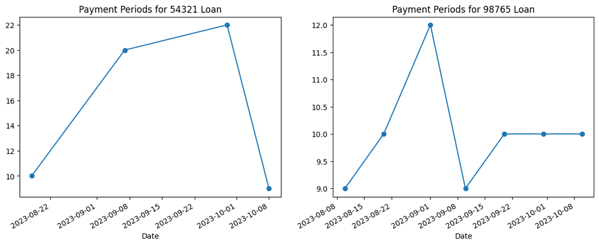

```python
figure, axis = plt.subplots(1, 2, figsize=(14, 5))
loan_54321_repayment.plot(y = 'payment_period', x = 'Date', marker = 'o', legend = False,
                          title = 'Payment Periods for 54321 Loan', ax = axis[0])
loan_98765_repayment.plot(y = 'payment_period', x = 'Date', marker = 'o', legend = False,
                          title = 'Payment Periods for 98765 Loan', ax = axis[1])
plt.show()
```

The plot illustrated the payment period between each payment for the two loans with irregular payment periods for 54321 and nearly stable payments period for 98765.

## Bonus

If we did not have the loan IDs and the descriptions are varying, how would you approach this?  
this question doesn't have one or straight answer first thing it purely depends on the data structure and several methods can be used e.g. this are not all the options but thats what i had on my mind right now

- **Pattern-based:** by defining pattern of keywords to search for and put several conditions on it.
- **Clustering and NLP:** for grouping several descriptions together.
- **Time series analysis:** to detect repayment patterns.
- **Rule based classification:** using transactions amounts to classify inflows and outflow of transactions.
- **Lastly** combining several methods together or even all of them.